# Appendix: Number of foods sold per outlet

An investigation into the number of foods sold per outlet between the three locations. First, we need to get the data into the correct format for the analysis.

```r
# Select variables to keep for comparison
vars <- c("Location", "outlet_type", "grain_cereal", "fresh_meat_poultry", "fresh_fish_shellfish", "procssd_fried_meat_poultry", "procssd_fried_fish", "trad_mixed_dishes", "modern_mixed_dishes", "soups_stews", "legumes_pulses", "fried_roots_tubers_plntn_pots", "nonfried_roots_tubers_plntn_pots", "fruits", "vegetables", "milk", "cakes_sweets", "savoury_snacks_pies", "sodas_sweetened_bevs", "sugar_sweet_spreads", "condiments", "fresh_juices", "tea_coffee", "alcohol", "nuts_seeds", "fats_oils", "eggs", "other")
# Load Kenya data
source("./tidy_gis_data_kenya.R")
outlets$Location <- "Nairobi" # Add in location for when join
outlets <- outlets[outlets$gis_itemname == 1 | outlets$gis_itemname == 2,] # Keep only outlets that sell food
kenya <- outlets[vars] # Subset variables
kenya$outlet_type[kenya$outlet_type == 1] <- "Supermarket"  # Rename to match Ghana data
  kenya$outlet_type[kenya$outlet_type == 2] <- "Shop"
  kenya$outlet_type[kenya$outlet_type == 3] <- "Kiosk"
  kenya$outlet_type[kenya$outlet_type == 4] <- "Vegetable/fruit/food stand/table top"
  kenya$outlet_type[kenya$outlet_type == 5] <- "Local vendor"
  kenya$outlet_type[kenya$outlet_type == 6] <- "Restaurant"
  kenya$outlet_type[kenya$outlet_type == 9] <- "Bar/pub"
  kenya$outlet_type[kenya$outlet_type == 96] <- "Other"
# Load Ghana data
source("./tidy_gis_data_ghana.R")
names(outlets)[names(outlets)=="location"] <- "Location" # Rename
outlets <- outlets[outlets$gis_itemname == "Food outlet with no advertising" | outlets$gis_itemname == "Food outlet with advertising",] # Keep only outlets that sell food
ghana <- outlets[vars] # Subset variables
ghana$outlet_type <- as.character(ghana$outlet_type) # Edit so matches Kenya data
  ghana$outlet_type[ghana$outlet_type == "Other (Specify)"] <- "Other" # Rename
  ghana$outlet_type[ghana$outlet_type == "Drinking Bar/pub"] <- "Bar/pub" # Rename
# Join together
fulldata <- rbind(kenya, ghana)
```

Ok, we need to calcuate the total number of food and drinks sold by each outlet. We can then have a look at how they vary between location.

```r
fulldata$foodcount <- rowSums(fulldata[3:28], na.rm=T) # Count number of food outlets
library(data.table)
fulldata <- as.data.table(fulldata)
meanitems <- fulldata[, list(mean = mean(foodcount), stddev = sd(foodcount)), by = c("Location")]
meanitems
```

| Location | mean | stddev |
| --- | --- | --- |
| Nairobi | 4.700201 | 3.690203 |
| Accra | 3.827848 | 2.703773 |
| Ho | 7.700980 | 4.733676 |

So we can see that the mean number of items sold was highest in Ho, and lowest in Accra which also had the smallest standard deviation (i.e. less spread around the mean). What about the proportion of outlets selling only single items?

```r
prop1 <- as.data.frame(table(fulldata$Location, fulldata$foodcount)) # Number of items sold by location
prop1 <- prop1[1:3,] # Select only outlets that sold one item
prop1$Var2 <- NULL # Drop number of items identifier
prop1$Total <- c(395, 204, 497) # Add in totals of outlets by location [table(fulldata$location)]
prop1$percent <- (prop1$Freq / prop1$Total) * 100 # Calculate percentage
prop1 # Print table
```

|  | Var1 | Freq | Total | percent |
| --- | --- | --- | --- | --- |
| 1 | Accra | 64 | 395 | 16.202532 |
| 2 | Ho | 17 | 204 | 8.333333 |
| 3 | Nairobi | 100 | 497 | 20.120724 |

So there were twice as many single item sellers in Accra than Ho, but the largest proportion was in Nairobi despite having a higher mean than Accra.

Lets compare the distributions of each location.

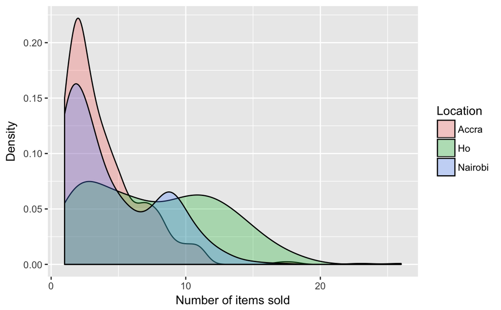

```r
library(ggplot2)
plot <- ggplot(fulldata, aes(x=foodcount, fill=Location)) + geom_density(alpha=.3) + ylab("Density") + xlab("Number of items sold")
ggsave("./Plots/foods_per_outlet.tiff", plot = plot, dpi = 300, width = 7, height = 7)
ggsave("./Plots low res/foods_per_outlet.tiff", plot = plot)
plot
```

While Nairobi has a greater proportion of outlets selling single items, Accra has a greater concentration selling few items. So <=2 items in Accra was 41.77%, Ho 18.62% and Nairobi 38.83%. For <=3 items it was 57.47% Accra, 52.11% Nairobi and 25.49% in Ho. For <=4 items, 69.12% Accra, 32.35% Ho and 59.35% Nairobi. Finally, for <= 5 it was 77.73% Accra, 38.23% Ho and 65.79% Nairobi.

The final thing to look at is the number of items sold by outlet type.

```r
meanbyoutlet <- fulldata[, list(mean = mean(foodcount), stddev = sd(foodcount)), by = c("outlet_type")]
meanbyoutlet
```

| outlet_type | mean | stddev |
| --- | --- | --- |
| Kiosk | 5.035433 | 3.435850 |
| Shop | 8.200980 | 4.572761 |
| Other | 3.125000 | 3.625626 |
| Local vendor | 3.692982 | 2.759143 |
| Vegetable/fruit/food stand/table top | 3.570667 | 2.375160 |
| Supermarket | 13.444444 | 5.198825 |
| Restaurant | 8.950000 | 4.839258 |
| Bar/pub | 2.931507 | 2.399819 |
| Bakery | 2.000000 | NA |
| Chop Bars (Ghana) | 6.363636 | 1.286291 |

[output cut: 2 more lines]

```r
prop2 <- as.data.frame(table(fulldata$outlet_type, fulldata$foodcount)) # Number of items sold by location
prop2 <- prop2[1:12,] # Select only outlets that sold one item
prop2$Var2 <- NULL # Drop number of items identifier
prop2$Total <- c(1, 73, 11, 2, 254, 114, 1, 32, 20, 204, 9, 375) # Add in totals of outlets by location [table(fulldata$outlet_type)]
prop2$percent <- (prop2$Freq / prop2$Total) * 100 # Calculate percentage
prop2 # Print table
```

|  | Var1 | Freq | Total | percent |
| --- | --- | --- | --- | --- |
| 1 | Bakery | 0 | 1 | 0.000000 |
| 2 | Bar/pub | 13 | 73 | 17.808219 |
| 3 | Chop Bars (Ghana) | 0 | 11 | 0.000000 |
| 4 | Cold stores (Ghana) | 1 | 2 | 50.000000 |
| 5 | Kiosk | 35 | 254 | 13.779528 |
| 6 | Local vendor | 27 | 114 | 23.684211 |
| 7 | Market | 0 | 1 | 0.000000 |
| 8 | Other | 16 | 32 | 50.000000 |
| 9 | Restaurant | 0 | 20 | 0.000000 |
| 10 | Shop | 19 | 204 | 9.313725 |

[output cut: 2 more lines]

How about two items?

```r
prop3 <- as.data.frame(table(fulldata$outlet_type, fulldata$foodcount)) # Number of items sold by location
prop3 <- prop3[1:24,] # Select only outlets that sold one item
temp <- as.data.table(prop3)
lesstwo <- temp[,sum(Freq, na.rm=T), by = "Var1"] # Combine counts
lesstwo$Var2 <- NULL # Drop number of items identifier
```

```
Adding new column 'Var2' then assigning NULL (deleting it).
```

```r
lesstwo$Total <- c(1, 73, 11, 2, 254, 114, 1, 32, 20, 204, 9, 375) # Add in totals of outlets by location [table(fulldata$outlet_type)]
lesstwo$percent <- (lesstwo$V1 / lesstwo$Total) * 100 # Calculate percentage
lesstwo # Print table
```

| Var1 | V1 | Total | percent |
| --- | --- | --- | --- |
| Bakery | 1 | 1 | 100.00000 |
| Bar/pub | 51 | 73 | 69.86301 |
| Chop Bars (Ghana) | 0 | 11 | 0.00000 |
| Cold stores (Ghana) | 1 | 2 | 50.00000 |
| Kiosk | 79 | 254 | 31.10236 |
| Local vendor | 55 | 114 | 48.24561 |
| Market | 0 | 1 | 0.00000 |
| Other | 20 | 32 | 62.50000 |
| Restaurant | 0 | 20 | 0.00000 |
| Shop | 36 | 204 | 17.64706 |

[output cut: 2 more lines]

Finally, what about less than 5 items?

```r
prop4 <- as.data.frame(table(fulldata$outlet_type, fulldata$foodcount)) # Number of items sold by location
prop4 <- prop4[1:48,] # Select only outlets that sold one item
temp <- as.data.table(prop4)
lessfive <- temp[,sum(Freq, na.rm=T), by = "Var1"] # Combine counts
lessfive$Var2 <- NULL # Drop number of items identifier
```

```
Adding new column 'Var2' then assigning NULL (deleting it).
```

```r
lessfive$Total <- c(1, 73, 11, 2, 254, 114, 1, 32, 20, 204, 9, 375) # Add in totals of outlets by location [table(fulldata$outlet_type)]
lessfive$percent <- (lessfive$V1 / lessfive$Total) * 100 # Calculate percentage
lessfive # Print table
```

| Var1 | V1 | Total | percent |
| --- | --- | --- | --- |
| Bakery | 1 | 1 | 100.00000 |
| Bar/pub | 61 | 73 | 83.56164 |
| Chop Bars (Ghana) | 0 | 11 | 0.00000 |
| Cold stores (Ghana) | 1 | 2 | 50.00000 |
| Kiosk | 138 | 254 | 54.33071 |
| Local vendor | 79 | 114 | 69.29825 |
| Market | 0 | 1 | 0.00000 |
| Other | 26 | 32 | 81.25000 |
| Restaurant | 3 | 20 | 15.00000 |
| Shop | 52 | 204 | 25.49020 |

[output cut: 2 more lines]